# Week 4: Causality Wrap-Up, Python Sequences and Libraries

## DSUA111: Data Science for Everyone, NYU, Fall 2020

### TA Jeff, `jpj251@nyu.edu`

- This slideshow: https://jjacobs.me/dsua111-sections/week-04
- All materials: https://github.com/jpowerj/dsua111-sections

## Outline

1. HW1 Feedback
2. Causality Wrap-Up
3. Python Sequences
4. Python Libraries

## 0. HW1 Feedback

- [NYU Classes -> Gradebook](https://newclasses.nyu.edu/portal/site/609e7da1-32c6-4cf5-bf0a-d7e589f4f5c5)

## 1. Causality Wrap-Up

*Where we left off:*

**Fundamental Problem of Causal Inference**: Forget Everything And Run?

[figure not shown]

## Face Everything And Rise

- Find good **comparison** cases: **Treatment Group** and **Control Group**
- "Statistical Matching"
  - Don't worry about the details, but tldr is:
  - Find the two **most similar** people, put one in Treatment Group, the other in Control Group, and compare their outcomes
  - Bam. If we can measure and take into account all variables that may be related to our causal hypothesis, this is **as close as we can possibly get** to "solving" FPCI
  - [Not on the midterm or final, but relevant in case you're despairing about FPCI]

## Controlled Experiments: How/Why Do They Help?

- Random Assignment: Vietnam War/Second Indochina War Draft
  - Key point: makes treatment and control groups similar, on average, without us having to do any work!
  - (e.g., don't need to worry about "pairing up" similar treatment+control units via statistical matching)
- No more Selection Effects
- Omitted variables are in BOTH Treatment and Control groups

## Complications: Selection

- Tldr: **Why** did this person (unit) end up in the **treatment** group? **Why** did this other person (unit) end up in the **control** group?
  - Are there systematic differences?
- Vietnam/Indochina Draft: Why can't we just study **[men who join the military]** versus **[men who don't]**, and take the difference as a causal estimate?

## Complications: Compliance

- We ideally want people **assigned** to the treatment group to **take** the treatment, and people **assigned** to the control group to **take** the control.
- "Compliance" is the degree to which this is actually true in your experiment
  - **High** compliance = most people actually took what they were assigned
  - **Low** compliance = lots of people who were assigned to treatment actually took control, and vice-versa
- What problems might there be with compliance in the Draft example?

## The Biggest Complication: Observational Data

- In observational studies, researchers have no control over assignment to treatment/control 😨
- On the one hand... Forget Everything And Run, if you can.
- On the other hand... statisticians over the last ~4 centuries have developed fancy causal inference tools/techniques to help us Face Everything And Rise!

## Causal Terminology for Observational Studies

[figure not shown]

## (This is... genuinely important + relevant imo)

[figure not shown]

from Hu (2020), ["Direct Effects"](https://phenomenalworld.org/analysis/direct-effects)

[figure not shown]

from Sampson, Winship, and Knight (2013), ["Translating Causal Claims: Principles and Strategies for Policy‐Relevant Criminology"](https://onlinelibrary.wiley.com/doi/abs/10.1111/1745-9133.12028)

[figure not shown]

from Bradford (2020), ["Observations on Police Shootings & Interracial Violence"](https://rpubs.com/johnbradford/policeShootingGraphs)

## 2. Python Sequences

Where we left off:

```python
my_string = "Jeff"
my_float = 5.5
my_string * my_float
```

```
---------------------------------------------------------------------------
TypeError                                 Traceback (most recent call last)
<ipython-input-113-e6906dc4821b> in <module>
      1 my_string = "Jeff"
      2 my_float = 5.5
----> 3 my_string * my_float

TypeError: can't multiply sequence by non-int of type 'float'
```

## Sequences?

[figure not shown]

(Lecture 6.2 slides, p. 5)

## Jeff's TLDR

- Lists: Ordered sequences of... anything (including lists themselves 🤯)

```python
my_basic_list = [1, "one", 1.0]
print(my_basic_list)
```

```
[1, 'one', 1.0]
```

```python
my_meta_list = [my_basic_list, 2, "two", 2.0, [3, "three", 3.0]]
print(my_meta_list)
```

```
[[1, 'one', 1.0], 2, 'two', 2.0, [3, 'three', 3.0]]
```

- This is **not** the same as

```python
my_non_meta_list = my_basic_list + [2, "two", 2.0] + [3, "three", 3.0]
print(my_non_meta_list)
```

```
[1, 'one', 1.0, 2, 'two', 2.0, 3, 'three', 3.0]
```

- ^(!!!)

## Ordered?

- We specify "ordered" only because there are also `set`s, which contain elements but have no notion of a "first", "second", "third" element

```python
ordered_list = [4, 3, 2, 1]
set(ordered_list)
```

```
{1, 2, 3, 4}
```

## Arrays are just fancier lists (for doing fancier math)

```python
ordered_array = np.array(ordered_list)
```

## Remember to import NumPy first!

```python
import numpy as np
ordered_array = np.array(ordered_list)
print(ordered_array)
print(ordered_list)
```

```
[4 3 2 1]
[4, 3, 2, 1]
```

```python
ordered_list.mean()
```

```
---------------------------------------------------------------------------
AttributeError                            Traceback (most recent call last)
<ipython-input-120-46a02c4663bc> in <module>
----> 1 ordered_list.mean()

AttributeError: 'list' object has no attribute 'mean'
```

```python
ordered_array.mean()
```

```
2.5
```

**Important difference**, though: NumPy arrays require that all elements be the **same type**!

...so what happens if they're different?

```python
no_bueno = np.array([1,"two",3.0])
no_bueno
```

```
array(['1', 'two', '3.0'], dtype='<U11')
```

```python
print(type(no_bueno[0]))
print(type(no_bueno[1]))
print(type(no_bueno[2]))
```

```
<class 'numpy.str_'>
<class 'numpy.str_'>
<class 'numpy.str_'>
```

## Bracket Madness

- `[` `]` (**square** brackets): `list`
- `{` `}` (**curly** brackets): `set` (or `dict`)
- `(` `)` (**parentheses**): `tuple`

```python
type([1, 2, 3])
```

```
list
```

```python
type({1, 2, 3})
```

```
set
```

```python
type({1: "one", 2: "two", 3: "three"})
```

```
dict
```

```python
type((1, 2, 3))
```

```
tuple
```

## 3. Python Libraries

(From most basic to most fancy)

**1. NumPy**: `import numpy as np`

$\rightarrow$ Math with **arrays**

**2. Pandas**: `import pandas as pd`

$\rightarrow$ Math with **Tables** (DataFrames)

**3. Matplotlib**: `import matplotlib.pyplot as plt`

$\rightarrow$ Visualizing NumPy/Pandas objects

**4. Statsmodels**: `import statsmodels.formula.api as smf`

$\rightarrow$ Statistical hypothesis testing

**5. Seaborn**: `import seaborn as sns`

$\rightarrow$ Visualizing statistical hypothesis tests

**6. Scikit-learn**: `import sklearn`

$\rightarrow$ Fancy machine learning things

## NumPy

```python
import numpy as np
cool_array = np.array([1, 2, 3, 4, 5])
cool_array.std()
```

```
1.4142135623730951
```

## Pandas

```python
import pandas as pd
cool_df = pd.DataFrame(
    {'x':[1,2,3,4,5,6,7,8],
     'y':[2,4,5,5,7,9,10,13],
     'z':[0,0,1,0,1,1,1,1]}
)
cool_df.head()
```

|  | x | y | z |
| --- | --- | --- | --- |
| 0 | 1 | 2 | 0 |
| 1 | 2 | 4 | 0 |
| 2 | 3 | 5 | 1 |
| 3 | 4 | 5 | 0 |
| 4 | 5 | 7 | 1 |

## Matplotlib

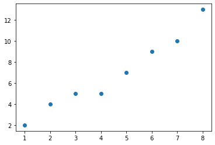

```python
import matplotlib.pyplot as plt
plt.scatter(cool_df['x'], cool_df['y'])
plt.show()
```

## Statsmodels

```python
import statsmodels.formula.api as smf
result = smf.ols('y ~ x', data=cool_df).fit()
print(result.summary().tables[1])
```

```
==============================================================================
                 coef    std err          t      P>|t|      [0.025      0.975]
------------------------------------------------------------------------------
Intercept      0.3929      0.614      0.640      0.546      -1.110       1.895
x              1.4405      0.122     11.846      0.000       1.143       1.738
==============================================================================
```

## Seaborn

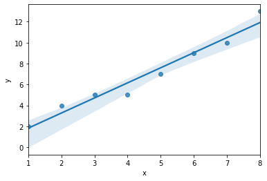

```python
import seaborn as sns
sns.regplot(x='x', y='y', data=cool_df);
```

## Scikit-learn

```python
import sklearn
```

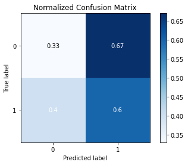

```python
import scikitplot as skplt
skplt.metrics.plot_confusion_matrix(classes, predictions, normalize=True)
plt.show()
```